# Week 8 Worksheet Exercises

Study design: Simulation-based power analysis for study design

## Aims

By the end of the session you will learn how to perform:

- Simulation of random variables
- Power analysis via simulation

## Setup

### Create a worksheet document

In Week 1 you set up `R` and `RStudio`, and an **RProject** folder (we called it “HSS8005_labs”) with an `.R` script and a `.qmd` or `.Rmd` document in it (we called these “Lab_1”). Ideally, you saved this on a cloud drive so you can access it from any computer (e.g. OneDrive). You will be working in this folder. If it’s missing, complete Exercise 3 from the Week 1 Worksheet.

Create a new Quarto markdown file (`.qmd`) for this session (e.g. “Lab_7.qmd”) and work in it to complete the exercises and report on your final analysis.

## R packages

```r
# Just in case we get errors asking that the package repositories be explicitly set when installing new packages:

options(repos = list(CRAN = "http://cran.rstudio.com/"))

# Install and load required packages

# We can use the {pacman} package to easily install and load several packages:
# ({pacman} itself may need installing if not yet installed)

pacman::p_load(
  tidyverse, sjlabelled, easystats,
  ggformula, ggeffects, marginaleffects,
  modelsummary, gtsummary,
  MASS                           # for the function `mvrnorm` to generate variables with pre-specified covariance structure
  )
```

## Exercise 1: basic data simulation

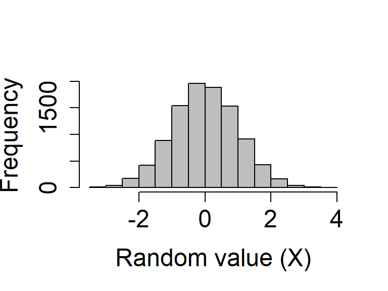

```r
rand_norms_10000 <- rnorm(n = 10000, mean = 0, sd = 1)

hist(rand_norms_10000, xlab = "Random value (X)", col = "grey",
     main = "", cex.lab = 1.5, cex.axis = 1.5)
```

- Compare the above distribution with a normal distribution that has a standard deviation of 2 instead of 1.
- Sample 10,000 new values in `rnorm` with `sd = 2` instead of `sd = 1` and create a new histogram with `hist`.
- To see what the distribution of sampled data might look like given a low sample size (e.g., 10), repeat the process of sampling from `rnorm(n = 10, mean = 0, sd = 1)` multiple times and look at the shape of the resulting histogram.

## Exercise 2: Simple randomised experiment

Work through *Example 1* in the Notes, making the following adjustments:

- change the seed number for the simulations to **8005**
- draw 300 samples instead of 100
- once you have done the exercise with a normally distributed grade outcome, try another simulation for a Fail/Pass binary outcome and adjust the model functions accordingly

## Exercise 3: (advanced) Multivariate distributions

Work through *Example 2* in the Notes, and as an exercise, try to expand the work in Exercise 2 above by simulating an additional covariate and modelling joint effects on that data.